# Plane Between Electrode Interface Testing

```python
import numpy as np
import random
import matplotlib.pyplot as plt
import plotly.offline as pyo
import plotly.graph_objects as go
pyo.init_notebook_mode()
```

### We are going to try to make a line that is editable in plane, which can be rotated on the "hinge" between the two electrodes.

### Geometry definitions

```python
# Collar points of the boreholes
collar1 = np.array([550,550,0])
collar2 = np.array([700,850,0])
# e1 and e2 are the real space representations of the electrodes
e1 = np.array([600,600,-100])
e2 = np.array([700,800,-150])
```

```python
# Check geometry by plotting it
x, y, z = [e1[0], e2[0]], [e1[1], e2[1]], [e1[2], e2[2]]
BH1 = [[e1[0], collar1[0]], [e1[1], collar1[1]], [e1[2], collar1[2]]]
BH2 = [[e2[0], collar2[0]], [e2[1], collar2[1]], [e2[2], collar2[2]]]
fig = go.Figure(data=[go.Scatter3d(x=x, y=y, z=z, name='hinge', mode='lines')])
fig.update_layout(title='Borehole MMR Trace Interface Testing, Unrotated')
fig.add_traces(go.Scatter3d(x=BH1[0], y=BH1[1], z=BH1[2], name='BH1'))
fig.add_traces(go.Scatter3d(x=BH2[0], y=BH2[1], z=BH2[2], name='BH2'))
fig.show()
```

[interactive chart not shown]

### v1 will be the vector that points between the electrodes, and the midpoint from e1 to e2 will be the hinge anchor for rotating the plane about v1

### Cross with +k to get v2 - as long as electrodes are not on top of each other this won't be a problem.

```python
v1 = e2 - e1 # Points from e1 to e2
v2 = np.cross(v1, [0,0,1])
plane_center = (e1 + e2) / 2
print(f"Center: {plane_center}")
```

[output not shown]

```python
# Normalize both direction vectors that define the plane to unit vectors
v1 = v1 / np.linalg.norm(v1)
v2 = v2 / np.linalg.norm(v2)
```

### Get corner points of the new plane, the perpendicular length will be 1/2 the straight line distance between the two electrodes

```python
ASPECT_RATIO = 0.5
DIM_X = np.linalg.norm(e2 - e1)
DIM_Y = ASPECT_RATIO * DIM_X

# Points are ordered.
p1, p2 = e1 + v2 * DIM_Y/2, e1 - v2 * DIM_Y/2
p3, p4 = e2 - v2 * DIM_Y/2, e2 + v2 * DIM_Y/2
print(DIM_X)
print(DIM_Y)
print(p1)
print(p2)
print(p3)
print(p4)
```

```
229.128784747792
114.564392373896
[ 651.23475383  574.38262309 -100.        ]
[ 548.76524617  625.61737691 -100.        ]
[ 648.76524617  825.61737691 -150.        ]
[ 751.23475383  774.38262309 -150.        ]
```

### Plot the points to see the plane

```python
rect = np.array([p1, p2, p3, p4, p1])
fig.add_traces(go.Scatter3d(x=rect[:,0], y=rect[:,1], z=rect[:,2], name='Calculated Plane', mode='lines'))
```

[interactive chart not shown]

### Now we create a new rectangle in a separate R2 domain with the same aspect ratio as the above rectangle, since we will just scale the given input onto the plane in real space

```python
X_len = 600.0
Y_height = X_len * ASPECT_RATIO
print(X_len, Y_height)

# In this space, e1 will be located at (0, Y_height/2)
#                e2 will be located at (X_len, Y_height/2)
```

```
600.0 300.0
```

### Choose some random points to simulate user input

```python
num_picks = 6
# Domain needs to be sorted
# X values are picked [0, X_len) yEI
pick_x = sorted([random.randint(0,X_len) for i in range(num_picks)])
# Y values are picked [0, Y_height) yEI
pick_y = [random.randint(0,Y_height) for i in range(num_picks)]

# Add points at beginning and end of line so that we have continuity with the borehole electrodes
pick_x.insert(0, 0)
pick_x.append(X_len)
pick_y.insert(0, Y_height / 2)
pick_y.append(Y_height / 2)
```

### Translate these points to realspace for plotting

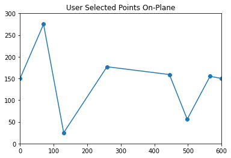

[interactive chart not shown]

```python
# First and last points are the electrodes - they were added above just for show
ptx = np.array(pick_x)
pty = np.array(pick_y)

pts = ((ptx / X_len * DIM_X)[..., np.newaxis] * v1 +
       ((pty-Y_height/2) / Y_height * DIM_Y)[..., np.newaxis] * v2) + e1

# Plot the user selected points
plt.xlim(0, X_len)
plt.ylim(0, Y_height)
plt.title("User Selected Points On-Plane")
plt.plot(pick_x, pick_y, 'o-')
plt.show()

fig.add_traces(go.Scatter3d(x=pts[:,0], y=pts[:,1], z=pts[:,2], name='Picked Points'))
fig.show()
```

### These points are rotated 180 degrees across v1 because our cross product above results in a plane normal that is -k, we can rotate this to a more natural representation, looking down at the plane

[interactive chart not shown]

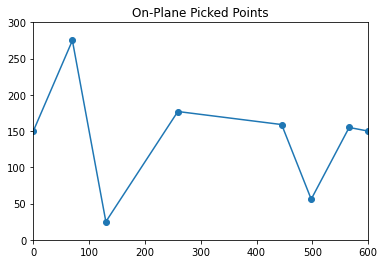

```python
ROTATION_ANGLE = 180

# Define a rotation function for the arbitrary rotation about v1
def rotate_local(list_points, angle_as_deg, rotation_axis, ref_center):
    rad = angle_as_deg * np.pi / 180
    a, b, c = rotation_axis[0], rotation_axis[1], rotation_axis[2]

    # Rotation Matrix for rotation about [vx, vy, vz]
    rot_matrix = np.array([[np.cos(rad) + a ** 2 * (1 - np.cos(rad)),
                            a * b * (1 - np.cos(rad)) - c * np.sin(rad),
                            a * c * (1 - np.cos(rad)) + b * np.sin(rad)],
                           [b * a * (1 - np.cos(rad)) + c * np.sin(rad),
                            np.cos(rad) + b ** 2 * (1 - np.cos(rad)),
                            b * c * (1 - np.cos(rad)) - a * np.sin(rad)],
                           [a * c * (1 - np.cos(rad)) - b * np.sin(rad),
                            b * c * (1 - np.cos(rad)) + a * np.sin(rad),
                            np.cos(rad) + c ** 2 * (1 - np.cos(rad))]])

    # Center and rotate to ref_center
    center_n_rotate = lambda pt: np.dot(rot_matrix, (pt - ref_center)) + ref_center
    out_arr = np.array([center_n_rotate(pt) for pt in list_points])
    return out_arr

# Plot the new rotated points
rotated_pts = rotate_local(pts, ROTATION_ANGLE, v1, plane_center)
rotated_rect = rotate_local(rect, ROTATION_ANGLE, v1, plane_center)

rotated_fig = go.Figure()
rotated_fig.update_layout(title='Borehole MMR Trace Interface Testing, Modelled Current Path')
rotated_fig.add_traces(go.Scatter3d(x=BH1[0], y=BH1[1], z=BH1[2], name='BH1'))
rotated_fig.add_traces(go.Scatter3d(x=BH2[0], y=BH2[1], z=BH2[2], name='BH2'))
rotated_fig.add_traces(go.Scatter3d(x=rotated_pts[:,0], y=rotated_pts[:,1], z=rotated_pts[:,2], name='Rotated'))
rotated_fig.show()

# Plotting
plt.xlim(0, X_len)
plt.ylim(0, Y_height)
plt.title("On-Plane Picked Points")
plt.plot(pick_x, pick_y, 'o-')
```

## Points can continue to be rotated about the hinge line to pick points. However currently this algorithm only allows the picking of points in a single unique plane.

## We can always rotate to other angles, perhaps constrain to a vein of mineralization with a set strike/dip

```python
# Try a rotation of 45 degrees.
ROTATION_ANGLE = 45
rotated_pts = rotate_local(rotated_pts, ROTATION_ANGLE, v1, plane_center)

rotated_fig = go.Figure()
rotated_fig.update_layout(title='Borehole MMR Trace Interface Testing, Modelled Current Path (2nd Rotation)')
rotated_fig.add_traces(go.Scatter3d(x=BH1[0], y=BH1[1], z=BH1[2], name='BH1'))
rotated_fig.add_traces(go.Scatter3d(x=BH2[0], y=BH2[1], z=BH2[2], name='BH2'))
rotated_fig.add_traces(go.Scatter3d(x=rotated_pts[:,0], y=rotated_pts[:,1], z=rotated_pts[:,2], name='Rotated'))
rotated_fig.show()
```

[interactive chart not shown]